# modeling

## Look for interaction term

```r
# Univariable regression for screening main effects
significant_vars <- c()  # save significant variables

for (var in names(model_data)[-c(28:30)]) {
  formula <- as.formula(paste("math_score ~", var))
  model <- lm(formula, data = model_data)
  if (summary(model)$coefficients[2, 4] < 0.05) {  # pvalue < 0.05
    significant_vars <- c(significant_vars, var)
  }
}
print(significant_vars)
```

```
##  [1] "gender"                        "ethnic_groupgroup_a"
##  [3] "ethnic_groupgroup_b"           "ethnic_groupgroup_c"
##  [5] "ethnic_groupgroup_e"           "parent_educassociates_degree"
##  [7] "parent_educbachelors_degree"   "parent_educhigh_school"
##  [9] "parent_educsome_high_school"   "lunch_type"
## [11] "parent_marital_statusdivorced" "parent_marital_statusmarried"
## [13] "parent_marital_statussingle"   "wkly_study_hours_5"
```

```r
# Generate interaction terms for significant variables
interaction_candidates <- combn(significant_vars, 2,
                                function(x) paste(x, collapse = ":"))
print(interaction_candidates)
```

```
##  [1] "gender:ethnic_groupgroup_a"
##  [2] "gender:ethnic_groupgroup_b"
##  [3] "gender:ethnic_groupgroup_c"
##  [4] "gender:ethnic_groupgroup_e"
##  [5] "gender:parent_educassociates_degree"
##  [6] "gender:parent_educbachelors_degree"
##  [7] "gender:parent_educhigh_school"
##  [8] "gender:parent_educsome_high_school"
##  [9] "gender:lunch_type"
## [10] "gender:parent_marital_statusdivorced"
## [11] "gender:parent_marital_statusmarried"
## [12] "gender:parent_marital_statussingle"
## [13] "gender:wkly_study_hours_5"
## [14] "ethnic_groupgroup_a:ethnic_groupgroup_b"
## [15] "ethnic_groupgroup_a:ethnic_groupgroup_c"
```

[output cut: 76 more lines]

We identify and test potential interaction terms based on the following criteria: Interactions involving key main effect variables, such as Gender, ethnic_group, and parent_educ. Variables with potential interaction effects inferred from background knowledge, including: Background Differences: e.g., Gender:ethnic_group or Gender:parent_educ. Study Habits: e.g., wkly_study_hours:lunch_type. Family Structure and Education Level: e.g., parent_marital_status:parent_educ.

```r
selected_interactions <- c(
  "gender:ethnic_groupgroup_a",
  "gender:parent_educbachelors_degree",
  "gender:lunch_type",
  "ethnic_groupgroup_a:parent_educbachelors_degree",
  "parent_educbachelors_degree:lunch_type",
  "lunch_type:wkly_study_hours_5",
  "parent_marital_statussingle:wkly_study_hours_5"
)
```

```r
# Construct model matrix containing only main effects
X_matrix_main <- model.matrix(~ . - 1, data = X)

selected_interactions <- c(
  "gender:ethnic_groupgroup_a",
  "gender:parent_educbachelors_degree",
  "gender:lunch_type",
  "ethnic_groupgroup_a:parent_educbachelors_degree",
  "parent_educbachelors_degree:lunch_type",
  "lunch_type:wkly_study_hours_5",
  "parent_marital_statussingle:wkly_study_hours_5"
)

# Construct model matrix containing main effects and interaction terms
formula_interactions <- as.formula(
  paste("~ . - 1 +", paste(selected_interactions, collapse = " + "))
)

X_matrix_inter <- model.matrix(formula_interactions, data = X)

y_vector <- model_data$math_score

# without interaction term LASSO
lasso_main <- cv.glmnet(X_matrix_main, y_vector, alpha = 1, nfolds = 5)
lambda_min_main <- lasso_main$lambda.min

# with interaction term LASSO
lasso_inter <- cv.glmnet(X_matrix_inter, y_vector, alpha = 1, nfolds = 5)
lambda_min_inter <- lasso_inter$lambda.min


# Extract the CV error (MSE) for the corresponding lambd
cv_mse_main <- lasso_main$cvm[which(lasso_main$lambda == lambda_min_main)]
cv_mse_inter <- lasso_inter$cvm[which(lasso_inter$lambda == lambda_min_inter)]

cat("no interaction term CV MSE:", cv_mse_main, "\n")
```

```
## no interaction term CV MSE: 191.7884
```

```r
cat("with interaction term CV MSE:", cv_mse_inter, "\n")
```

```
## with interaction term CV MSE: 188.5677
```

```r
pred_main <- predict(lasso_main$glmnet.fit, newx = X_matrix_main, s = lambda_min_main)
pred_inter <- predict(lasso_inter$glmnet.fit, newx = X_matrix_inter, s = lambda_min_inter)

# RSS and TSS
rss_main <- sum((y_vector - pred_main)^2)
rss_inter <- sum((y_vector - pred_inter)^2)
tss <- sum((y_vector - mean(y_vector))^2)

coef_main <- coef(lasso_main, s = lambda_min_main)
coef_inter <- coef(lasso_inter, s = lambda_min_inter)

k_main <- sum(coef_main != 0) - 1
k_inter <- sum(coef_inter != 0) - 1

r2_main <- 1 - (rss_main / tss)
r2_inter <- 1 - (rss_inter / tss)
adj_r2_main <- 1 - (1 - r2_main)*((n - 1)/(n - k_main - 1))
adj_r2_inter <- 1 - (1 - r2_inter)*((n - 1)/(n - k_inter - 1))

cat("no interaction term R²:", r2_main, "\n")
```

```
## no interaction term R²: 0.2528167
```

```r
cat("with interaction term R²:", r2_inter, "\n")
```

```
## with interaction term R²: 0.2662237
```

```r
predictions <- predict(lasso_model$glmnet.fit, newx = X_matrix, s = lambda_min)
residuals <- y_vector - predictions
```

# normality

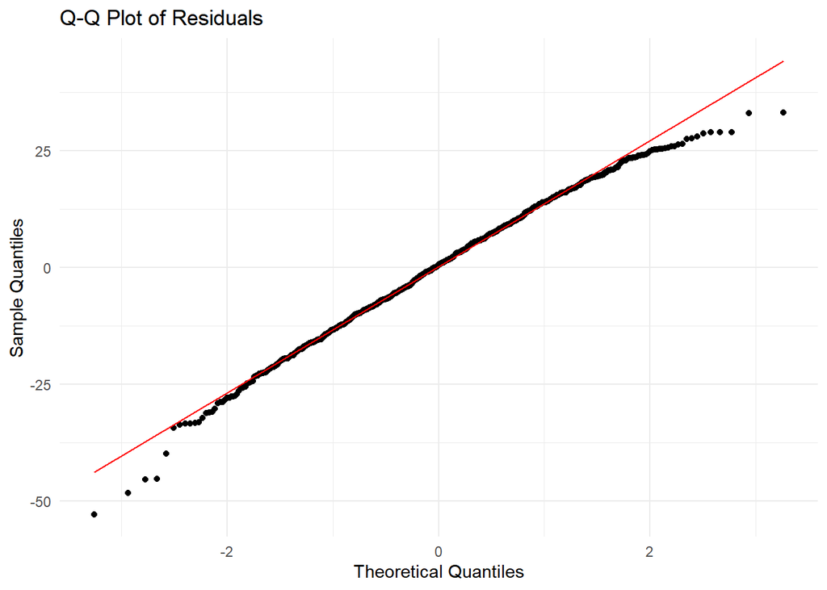

```r
residuals_df <- data.frame(residuals = residuals)

ggplot(residuals_df, aes(sample = residuals)) +
  stat_qq() +
  stat_qq_line(col = "red") +
  labs(title = "Q-Q Plot of Residuals",
       x = "Theoretical Quantiles",
       y = "Sample Quantiles") +
  theme_minimal()
```

```r
shapiro_result <- shapiro.test(residuals)
cat("Shapiro-Wilk test p-value:", shapiro_result$p.value, "\n")
```

```
## Shapiro-Wilk test p-value: 0.0003726845
```

```r
if (shapiro_result$p.value < 0.05) {
  cat("Residuals may deviate from normal distribution\n")
} else {
  cat("Residuals do not reject the null hypothesis of normality\n")
}
```

```
## Residuals may deviate from normal distribution
```

## constant variance

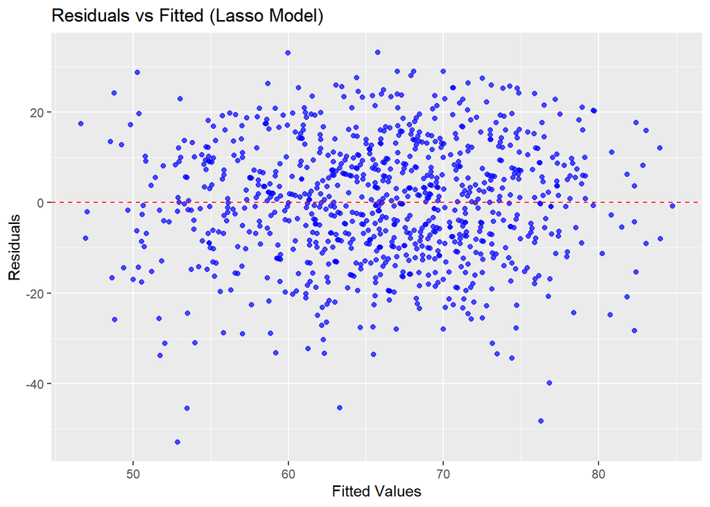

```r
predictions <- predict(lasso_model$glmnet.fit, newx = X_matrix, s = lambda_min)
residuals <- y_vector - predictions

residuals_df <- data.frame(
  Fitted = predictions,
  Residuals = residuals
)
colnames(residuals_df) <- c("Fitted", "Residuals")


# Plot Residuals vs Fitted
ggplot(residuals_df, aes(x = Fitted, y = Residuals)) +
  geom_point(color = "blue", alpha = 0.7) +  # Points
  geom_hline(yintercept = 0, color = "red", linetype = "dashed") +
  labs(
    x = "Fitted Values",
    y = "Residuals",
    title = "Residuals vs Fitted (Lasso Model)"
  )
```

## check for independence

```r
dw_result <- dwtest(residuals ~ predictions)
cat("Durbin-Watson test p-value:", dw_result$p.value, "\n")
```

```
## Durbin-Watson test p-value: 0.4779607
```

```r
if (dw_result$p.value < 0.05) {
  cat("Residuals exhibit autocorrelation\n")
} else {
  cat("No significant autocorrelation was detected\n")
}
```

```
## No significant autocorrelation was detected
```

## VIF

```r
selected_vars <- rownames(lasso_coef)[which(lasso_coef != 0)]
selected_vars <- selected_vars[selected_vars != "(Intercept)"]
formula_selected <- as.formula(paste("y_vector ~", paste(selected_vars, collapse = "+")))
lm_selected <- lm(formula_selected, data = X)
vif_values <- vif(lm_selected)
cat("VIF values:\n")
```

```
## VIF values:
```

```r
print(vif_values)
```

```
##                        gender           ethnic_groupgroup_a
##                      1.021478                      1.261773
##           ethnic_groupgroup_c           ethnic_groupgroup_d
##                      1.593147                      1.558779
##           ethnic_groupgroup_e  parent_educassociates_degree
##                      1.359950                      3.817922
##   parent_educbachelors_degree        parent_educhigh_school
##                      2.675154                      3.588578
##     parent_educmasters_degree       parent_educsome_college
##                      1.947286                      3.877968
##   parent_educsome_high_school                    lunch_type
##                      3.431080                      1.015554
##                     test_prep parent_marital_statusdivorced
##                      1.028895                      1.334796
##  parent_marital_statusmarried  parent_marital_statuswidowed
##                      1.373453                      1.094416
##           practice_sportnever       practice_sportregularly
##                      1.109325                      1.104681
##                   nr_siblings               transport_means
##                      1.025304                      1.048333
##            wkly_study_hours_5           wkly_study_hours_10
##                      1.104254                      1.106978
```

```r
basic_lm <- lm(y_vector ~ X_matrix)

# Find a shift value to ensure positivity
shift_value <- abs(min(y_vector)) + 1
y_vector_shifted <- y_vector + shift_value

# Refit the basic linear model with shifted response
basic_lm <- lm(y_vector_shifted ~ X_matrix)

# Now apply boxcox
boxcox_result <- boxcox(basic_lm, lambda = seq(-2, 2, by = 0.1))
```

[figure not shown]

```r
# Use boxcox() to find the optimal lambda value
lambda_opt <- boxcox_result$x[which.max(boxcox_result$y)]
cat("Optimal lambda for Box-Cox:", lambda_opt, "\n")
```

```
## Optimal lambda for Box-Cox: 1.313131
```

```r
# 2. Transform y_vector based on the optimal lambda
if (lambda_opt == 0) {
  # If lambda = 0, the transform is log(y)
  y_transformed <- log(y_vector)
} else {
  # For lambda != 0, use the standard Box-Cox formula
  y_transformed <- (y_vector^lambda_opt - 1) / lambda_opt
}

# 3. Fit a LASSO model using the transformed response
lasso_model_boxcox <- cv.glmnet(X_matrix, y_transformed, alpha = 1, nfolds = 5)
lambda_min_boxcox <- lasso_model_boxcox$lambda.min

# Extract coefficients for the best model on the transformed scale
lasso_coef_boxcox <- coef(lasso_model_boxcox, s = lambda_min_boxcox)
print(lasso_coef_boxcox)
```

```
## 28 x 1 sparse Matrix of class "dgCMatrix"
##                                        s1
## (Intercept)                   139.2272481
## gender                         17.3571145
## ethnic_groupgroup_a            -4.6335976
## ethnic_groupgroup_b             .
## ethnic_groupgroup_c            -0.5158639
## ethnic_groupgroup_d            10.1161687
## ethnic_groupgroup_e            31.4694268
## parent_educassociates_degree   10.3729680
## parent_educbachelors_degree    15.4250585
## parent_educhigh_school         -8.8503199
## parent_educmasters_degree      16.6568103
## parent_educsome_college         6.4784142
## parent_educsome_high_school    -4.2699421
## lunch_type                     39.1011661
## test_prep                       1.8879325
## parent_marital_statusdivorced  -0.6366352
## parent_marital_statusmarried    9.4056072
## parent_marital_statussingle     .
## parent_marital_statuswidowed   12.2654685
## practice_sportnever            -6.2228514
## practice_sportregularly         1.7550983
## practice_sportsometimes         .
## is_first_child                  .
## nr_siblings                     0.3528815
## transport_means                 0.5621867
## wkly_study_hours_5            -12.4383902
## wkly_study_hours_10             1.8621021
## wkly_study_hours10_may          .
```

```r
# 4. Compare model performance
# For example, compare CV MSE with and without transformation
cv_mse_boxcox <- lasso_model_boxcox$cvm[which(lasso_model_boxcox$lambda == lambda_min_boxcox)]
cat("Box-Cox transformed model CV MSE:", cv_mse_boxcox, "\n")
```

```
## Box-Cox transformed model CV MSE: 2548.54
```

# Reading_model

```r
# Select predictors, excluding the score columns
X_reading <- model_data %>%
  select(-math_score, -reading_score, -writing_score)

# Define the response variable
y_reading <- model_data$reading_score

# The initial full-variable model for reading_score
full_model_reading <- lm(reading_score ~ ., data = model_data[, c(colnames(X_reading), "reading_score")])

# Perform backward elimination
backward_model_reading <- stepAIC(full_model_reading, direction = "backward")
```

```
## Start:  AIC=4724.18
## reading_score ~ gender + ethnic_groupgroup_a + ethnic_groupgroup_b +
##     ethnic_groupgroup_c + ethnic_groupgroup_d + ethnic_groupgroup_e +
##     parent_educassociates_degree + parent_educbachelors_degree +
##     parent_educhigh_school + parent_educmasters_degree + parent_educsome_college +
##     parent_educsome_high_school + lunch_type + test_prep + parent_marital_statusdivorced +
##     parent_marital_statusmarried + parent_marital_statussingle +
##     parent_marital_statuswidowed + practice_sportnever + practice_sportregularly +
##     practice_sportsometimes + is_first_child + nr_siblings +
##     transport_means + wkly_study_hours_5 + wkly_study_hours_10 +
##     wkly_study_hours10_may
##
##                                 Df Sum of Sq    RSS    AIC
## - parent_marital_statussingle    1       0.0 159530 4722.2
## - practice_sportsometimes        1       1.6 159531 4722.2
## - is_first_child                 1       9.9 159540 4722.2
## - transport_means                1      12.9 159543 4722.3
## - practice_sportnever            1      13.5 159543 4722.3
## - parent_marital_statusdivorced  1      14.0 159544 4722.3
## - nr_siblings                    1      16.0 159546 4722.3
## - practice_sportregularly        1      19.8 159549 4722.3
## - parent_educsome_high_school    1      29.7 159559 4722.4
## - parent_educhigh_school         1      34.8 159564 4722.4
## - wkly_study_hours_5             1      37.0 159567 4722.4
## - ethnic_groupgroup_a            1      45.7 159575 4722.4
## - wkly_study_hours_10            1      74.1 159604 4722.6
## - ethnic_groupgroup_b            1      84.3 159614 4722.7
## - test_prep                      1      97.2 159627 4722.7
## - wkly_study_hours10_may         1      98.0 159628 4722.7
## - ethnic_groupgroup_c            1     137.1 159667 4723.0
## - parent_marital_statuswidowed   1     256.8 159787 4723.6
## - parent_marital_statusmarried   1     283.9 159814 4723.8
## <none>                                       159530 4724.2
## - parent_educsome_college        1     479.8 160009 4724.9
## - ethnic_groupgroup_d            1     712.7 160242 4726.2
## - parent_educassociates_degree   1    1119.7 160649 4728.5
## - parent_educbachelors_degree    1    1445.4 160975 4730.3
## - ethnic_groupgroup_e            1    1449.0 160979 4730.3
## - parent_educmasters_degree      1    2231.2 161761 4734.7
## - gender                         1   10910.0 170440 4781.9
```

[output cut: 469 more lines]

```
##     parent_marital_statusmarried + wkly_study_hours_10 + wkly_study_hours10_may
##
##                                Df Sum of Sq    RSS    AIC
## <none>                                      160637 4698.4
## - wkly_study_hours_10           1     656.8 161293 4700.1
## - ethnic_groupgroup_d           1    1179.7 161816 4703.0
## - wkly_study_hours10_may        1    1365.1 162002 4704.1
## - parent_marital_statusmarried  1    1512.7 162149 4704.9
## - parent_educsome_college       1    1528.8 162165 4705.0
## - ethnic_groupgroup_e           1    2187.7 162824 4708.6
## - parent_educassociates_degree  1    3448.5 164085 4715.6
## - parent_educbachelors_degree   1    3606.2 164243 4716.4
## - parent_educmasters_degree     1    4239.4 164876 4719.9
## - gender                        1   11233.3 171870 4757.4
## - lunch_type                    1   11476.3 172113 4758.7
```

```r
# Display the summary of the final model
summary(backward_model_reading)
```

```
##
## Call:
## lm(formula = reading_score ~ gender + ethnic_groupgroup_d + ethnic_groupgroup_e +
##     parent_educassociates_degree + parent_educbachelors_degree +
##     parent_educmasters_degree + parent_educsome_college + lunch_type +
##     parent_marital_statusmarried + wkly_study_hours_10 + wkly_study_hours10_may,
##     data = model_data[, c(colnames(X_reading), "reading_score")])
##
## Residuals:
##     Min      1Q  Median      3Q     Max
## -45.306  -9.007   0.429   9.641  32.671
##
## Coefficients:
##                              Estimate Std. Error t value Pr(>|t|)
## (Intercept)                   59.6426     1.3379  44.578  < 2e-16 ***
## gender                        -7.0965     0.8995  -7.889 8.91e-15 ***
## ethnic_groupgroup_d            2.7144     1.0617   2.557 0.010736 *
## ethnic_groupgroup_e            4.7991     1.3785   3.481 0.000523 ***
## parent_educassociates_degree   5.2861     1.2093   4.371 1.38e-05 ***
## parent_educbachelors_degree    6.8839     1.5401   4.470 8.84e-06 ***
## parent_educmasters_degree      9.6802     1.9974   4.846 1.48e-06 ***
## parent_educsome_college        3.4823     1.1965   2.910 0.003700 **
## lunch_type                     7.4967     0.9402   7.974 4.70e-15 ***
## parent_marital_statusmarried   2.6168     0.9039   2.895 0.003884 **
## wkly_study_hours_10            2.6638     1.3963   1.908 0.056754 .
## wkly_study_hours10_may         2.7929     1.0155   2.750 0.006078 **
## ---
## Signif. codes:  0 '***' 0.001 '**' 0.01 '*' 0.05 '.' 0.1 ' ' 1
##
## Residual standard error: 13.43 on 890 degrees of freedom
## Multiple R-squared:  0.1886, Adjusted R-squared:  0.1786
## F-statistic: 18.81 on 11 and 890 DF,  p-value: < 2.2e-16
```

## criteria-based

```r
# Perform stepwise selection based on AIC using stepAIC
aic_model_reading <- stepAIC(full_model_reading, direction = "both", k = 2)
```

```
## Start:  AIC=4724.18
## reading_score ~ gender + ethnic_groupgroup_a + ethnic_groupgroup_b +
##     ethnic_groupgroup_c + ethnic_groupgroup_d + ethnic_groupgroup_e +
##     parent_educassociates_degree + parent_educbachelors_degree +
##     parent_educhigh_school + parent_educmasters_degree + parent_educsome_college +
##     parent_educsome_high_school + lunch_type + test_prep + parent_marital_statusdivorced +
##     parent_marital_statusmarried + parent_marital_statussingle +
##     parent_marital_statuswidowed + practice_sportnever + practice_sportregularly +
##     practice_sportsometimes + is_first_child + nr_siblings +
##     transport_means + wkly_study_hours_5 + wkly_study_hours_10 +
##     wkly_study_hours10_may
##
##                                 Df Sum of Sq    RSS    AIC
## - parent_marital_statussingle    1       0.0 159530 4722.2
## - practice_sportsometimes        1       1.6 159531 4722.2
## - is_first_child                 1       9.9 159540 4722.2
## - transport_means                1      12.9 159543 4722.3
## - practice_sportnever            1      13.5 159543 4722.3
## - parent_marital_statusdivorced  1      14.0 159544 4722.3
## - nr_siblings                    1      16.0 159546 4722.3
## - practice_sportregularly        1      19.8 159549 4722.3
## - parent_educsome_high_school    1      29.7 159559 4722.4
## - parent_educhigh_school         1      34.8 159564 4722.4
## - wkly_study_hours_5             1      37.0 159567 4722.4
## - ethnic_groupgroup_a            1      45.7 159575 4722.4
## - wkly_study_hours_10            1      74.1 159604 4722.6
## - ethnic_groupgroup_b            1      84.3 159614 4722.7
## - test_prep                      1      97.2 159627 4722.7
## - wkly_study_hours10_may         1      98.0 159628 4722.7
## - ethnic_groupgroup_c            1     137.1 159667 4723.0
## - parent_marital_statuswidowed   1     256.8 159787 4723.6
## - parent_marital_statusmarried   1     283.9 159814 4723.8
## <none>                                       159530 4724.2
## - parent_educsome_college        1     479.8 160009 4724.9
## - ethnic_groupgroup_d            1     712.7 160242 4726.2
## - parent_educassociates_degree   1    1119.7 160649 4728.5
## - parent_educbachelors_degree    1    1445.4 160975 4730.3
## - ethnic_groupgroup_e            1    1449.0 160979 4730.3
## - parent_educmasters_degree      1    2231.2 161761 4734.7
## - gender                         1   10910.0 170440 4781.9
```

[output cut: 605 more lines]

```
## + practice_sportnever            1       7.3 160629 4700.4
## + ethnic_groupgroup_a            1       7.0 160630 4700.4
## + ethnic_groupgroup_b            1       1.6 160635 4700.4
## + is_first_child                 1       0.7 160636 4700.4
## + parent_marital_statussingle    1       0.0 160637 4700.4
## - ethnic_groupgroup_d            1    1179.7 161816 4703.0
## - wkly_study_hours10_may         1    1365.1 162002 4704.1
## - parent_marital_statusmarried   1    1512.7 162149 4704.9
## - parent_educsome_college        1    1528.8 162165 4705.0
## - ethnic_groupgroup_e            1    2187.7 162824 4708.6
## - parent_educassociates_degree   1    3448.5 164085 4715.6
## - parent_educbachelors_degree    1    3606.2 164243 4716.4
## - parent_educmasters_degree      1    4239.4 164876 4719.9
## - gender                         1   11233.3 171870 4757.4
## - lunch_type                     1   11476.3 172113 4758.7
```

```r
summary(aic_model_reading)
```

```
##
## Call:
## lm(formula = reading_score ~ gender + ethnic_groupgroup_d + ethnic_groupgroup_e +
##     parent_educassociates_degree + parent_educbachelors_degree +
##     parent_educmasters_degree + parent_educsome_college + lunch_type +
##     parent_marital_statusmarried + wkly_study_hours_10 + wkly_study_hours10_may,
##     data = model_data[, c(colnames(X_reading), "reading_score")])
##
## Residuals:
##     Min      1Q  Median      3Q     Max
## -45.306  -9.007   0.429   9.641  32.671
##
## Coefficients:
##                              Estimate Std. Error t value Pr(>|t|)
## (Intercept)                   59.6426     1.3379  44.578  < 2e-16 ***
## gender                        -7.0965     0.8995  -7.889 8.91e-15 ***
## ethnic_groupgroup_d            2.7144     1.0617   2.557 0.010736 *
## ethnic_groupgroup_e            4.7991     1.3785   3.481 0.000523 ***
## parent_educassociates_degree   5.2861     1.2093   4.371 1.38e-05 ***
## parent_educbachelors_degree    6.8839     1.5401   4.470 8.84e-06 ***
## parent_educmasters_degree      9.6802     1.9974   4.846 1.48e-06 ***
## parent_educsome_college        3.4823     1.1965   2.910 0.003700 **
## lunch_type                     7.4967     0.9402   7.974 4.70e-15 ***
## parent_marital_statusmarried   2.6168     0.9039   2.895 0.003884 **
## wkly_study_hours_10            2.6638     1.3963   1.908 0.056754 .
## wkly_study_hours10_may         2.7929     1.0155   2.750 0.006078 **
## ---
## Signif. codes:  0 '***' 0.001 '**' 0.01 '*' 0.05 '.' 0.1 ' ' 1
##
## Residual standard error: 13.43 on 890 degrees of freedom
## Multiple R-squared:  0.1886, Adjusted R-squared:  0.1786
## F-statistic: 18.81 on 11 and 890 DF,  p-value: < 2.2e-16
```

```r
# Perform stepwise selection based on BIC using stepAIC
bic_model_reading <- stepAIC(full_model_reading, direction = "both", k = log(nrow(model_data)))
```

```
## Start:  AIC=4858.71
## reading_score ~ gender + ethnic_groupgroup_a + ethnic_groupgroup_b +
##     ethnic_groupgroup_c + ethnic_groupgroup_d + ethnic_groupgroup_e +
##     parent_educassociates_degree + parent_educbachelors_degree +
##     parent_educhigh_school + parent_educmasters_degree + parent_educsome_college +
##     parent_educsome_high_school + lunch_type + test_prep + parent_marital_statusdivorced +
##     parent_marital_statusmarried + parent_marital_statussingle +
##     parent_marital_statuswidowed + practice_sportnever + practice_sportregularly +
##     practice_sportsometimes + is_first_child + nr_siblings +
##     transport_means + wkly_study_hours_5 + wkly_study_hours_10 +
##     wkly_study_hours10_may
##
##                                 Df Sum of Sq    RSS    AIC
## - parent_marital_statussingle    1       0.0 159530 4851.9
## - practice_sportsometimes        1       1.6 159531 4851.9
## - is_first_child                 1       9.9 159540 4852.0
## - transport_means                1      12.9 159543 4852.0
## - practice_sportnever            1      13.5 159543 4852.0
## - parent_marital_statusdivorced  1      14.0 159544 4852.0
## - nr_siblings                    1      16.0 159546 4852.0
## - practice_sportregularly        1      19.8 159549 4852.0
## - parent_educsome_high_school    1      29.7 159559 4852.1
## - parent_educhigh_school         1      34.8 159564 4852.1
## - wkly_study_hours_5             1      37.0 159567 4852.1
## - ethnic_groupgroup_a            1      45.7 159575 4852.2
## - wkly_study_hours_10            1      74.1 159604 4852.3
## - ethnic_groupgroup_b            1      84.3 159614 4852.4
## - test_prep                      1      97.2 159627 4852.5
## - wkly_study_hours10_may         1      98.0 159628 4852.5
## - ethnic_groupgroup_c            1     137.1 159667 4852.7
## - parent_marital_statuswidowed   1     256.8 159787 4853.4
## - parent_marital_statusmarried   1     283.9 159814 4853.5
## - parent_educsome_college        1     479.8 160009 4854.6
## - ethnic_groupgroup_d            1     712.7 160242 4855.9
## - parent_educassociates_degree   1    1119.7 160649 4858.2
## <none>                                       159530 4858.7
## - parent_educbachelors_degree    1    1445.4 160975 4860.0
## - ethnic_groupgroup_e            1    1449.0 160979 4860.1
## - parent_educmasters_degree      1    2231.2 161761 4864.4
## - gender                         1   10910.0 170440 4911.6
```

[output cut: 749 more lines]

```
## + practice_sportsometimes        1      89.6 161730 4755.4
## + ethnic_groupgroup_c            1      88.1 161732 4755.4
## + parent_marital_statusdivorced  1      59.5 161760 4755.6
## + transport_means                1      20.0 161800 4755.8
## + nr_siblings                    1      15.5 161804 4755.8
## + wkly_study_hours10_may         1      10.6 161809 4755.8
## + practice_sportnever            1       5.1 161815 4755.9
## + wkly_study_hours_10            1       1.9 161818 4755.9
## + parent_marital_statussingle    1       0.7 161819 4755.9
## + is_first_child                 1       0.4 161819 4755.9
## - parent_educassociates_degree   1    3332.9 165153 4760.7
## - parent_educbachelors_degree    1    3590.7 165410 4762.1
## - parent_educmasters_degree      1    4404.0 166224 4766.5
## - gender                         1   11091.4 172911 4802.1
## - lunch_type                     1   11405.8 173225 4803.7
```

```r
summary(bic_model_reading)
```

```
##
## Call:
## lm(formula = reading_score ~ gender + ethnic_groupgroup_e + parent_educassociates_degree +
##     parent_educbachelors_degree + parent_educmasters_degree +
##     parent_educsome_college + lunch_type + parent_marital_statusmarried +
##     wkly_study_hours_5, data = model_data[, c(colnames(X_reading),
##     "reading_score")])
##
## Residuals:
##     Min      1Q  Median      3Q     Max
## -46.174  -9.104   0.269   9.869  32.184
##
## Coefficients:
##                              Estimate Std. Error t value Pr(>|t|)
## (Intercept)                   63.1736     1.1526  54.812  < 2e-16 ***
## gender                        -7.0458     0.9011  -7.819 1.50e-14 ***
## ethnic_groupgroup_e            3.9713     1.3447   2.953  0.00323 **
## parent_educassociates_degree   5.1851     1.2097   4.286 2.01e-05 ***
## parent_educbachelors_degree    6.8652     1.5431   4.449 9.72e-06 ***
## parent_educmasters_degree      9.8431     1.9977   4.927 9.95e-07 ***
## parent_educsome_college        3.4995     1.1976   2.922  0.00356 **
## lunch_type                     7.4668     0.9417   7.929 6.57e-15 ***
## parent_marital_statusmarried   2.5314     0.9052   2.796  0.00528 **
## wkly_study_hours_5            -2.9036     1.0177  -2.853  0.00443 **
## ---
## Signif. codes:  0 '***' 0.001 '**' 0.01 '*' 0.05 '.' 0.1 ' ' 1
##
## Residual standard error: 13.47 on 892 degrees of freedom
## Multiple R-squared:  0.1826, Adjusted R-squared:  0.1744
## F-statistic: 22.14 on 9 and 892 DF,  p-value: < 2.2e-16
```

```r
# Prepare the predictors (X) and response variable (y) for reading_score
X_matrix_reading <- model.matrix(~ . - 1, data = X_reading)  # Convert predictors to a matrix
y_vector_reading <- as.numeric(model_data$reading_score)  # Response variable as a numeric vector

# Fit Lasso model with cross-validation
lasso_model_reading <- cv.glmnet(X_matrix_reading, y_vector_reading, alpha = 1, nfolds = 5)

# Extract the best lambda (lambda.min)
lambda_min_reading <- lasso_model_reading$lambda.min

# Get the coefficients at the best lambda
lasso_coef_reading <- coef(lasso_model_reading, s = lambda_min_reading)
print(lasso_coef_reading)
```

```
## 28 x 1 sparse Matrix of class "dgCMatrix"
##                                        s1
## (Intercept)                   64.08958043
## gender                        -6.72567919
## ethnic_groupgroup_a            .
## ethnic_groupgroup_b            .
## ethnic_groupgroup_c            .
## ethnic_groupgroup_d            1.99359831
## ethnic_groupgroup_e            4.12451014
## parent_educassociates_degree   2.69431579
## parent_educbachelors_degree    3.96278477
## parent_educhigh_school        -2.77289378
## parent_educmasters_degree      6.52964895
## parent_educsome_college        0.85407440
## parent_educsome_high_school   -0.94454324
## lunch_type                     7.03615291
## test_prep                      0.75826344
## parent_marital_statusdivorced -0.33267683
## parent_marital_statusmarried   2.35095243
## parent_marital_statussingle    .
## parent_marital_statuswidowed   2.47758577
## practice_sportnever            .
## practice_sportregularly       -0.04494952
## practice_sportsometimes        0.23371278
## is_first_child                 .
## nr_siblings                    .
## transport_means                .
## wkly_study_hours_5            -2.27046966
## wkly_study_hours_10            .
## wkly_study_hours10_may         0.08756563
```